# Race and child welfare: bias across policy domains

Frank Edwards

June 1, 2016

# Introduction

Racial inequalities in foster care are not merely a function of child maltreatment. Many have argued that inequality in child welfare outcomes across racial groups is likely a function of statistical selection, rather than biased decision-making among child welfare officials. However, child welfare agencies are only one potential source of structural racism that might bias child welfare agencies toward higher levels of intervention with families of color. We are unlikely to explain racial inequality in child welfare outcomes if we restrict our anlaysis of official bias to child welfare agencies alone.

It is well known that racial inequalities in criminal justice contact and incarceration are partially explained by racially biased policing, racially biased criminal justice decision making, and deep structural inequalities between groups.

However, it is unlikely that exposure to material risk factors alone explains inequality in child welfare system outcomes. A maltreatment report or a child’s entry into foster care are the products of an elaborate chain of state action.

This paper evaluates the extent to which racial inequalities in child welfare outcomes are explained by the racial inequalities in its criminal justice system.

# Analytic strategy

States vary tremendously in levels of inequality in their child welfare systems. I exploit this variation to evaluate whether racialization of social policy helps to explain variation in racial and ethnic inequality in child welfare case outcomes.

I suggest that racial inequality in state social policy in criminal justice and social welfare programs predicts racial inequality in child welfare case outcomes. Three potential mechanisms may explain an observed association:

*Could add diagrams for each theory*

1. **Systematic discrimination:** Unequal outcomes in one policy domain indicate a political culture of racial bias. In this case, the association between racial inequality in child welfare outcomes and racial inequality in another policy domain is SPURIOUS with a latent (unobserved) difference in racial politics across states. This difference in the racial politics of social policy may lead families of color to heightened surveilance and biased decision making in street-level bureaucracies.
2. **Structural inequality:** Social policy affects the risk of child maltreatment. Incarceration and criminal justice contact have a causal relationship to foster care entry, and have a series of collateral consequences that are very likely to affect the incidence of child maltreatment. The racial politics of social policy may have a direct relationship to racial inequality in child welfare outcomes through their effects on structural racial inequality.
3. **Selection:** Some unmeasured feature associated with group membership may simulataneously cause increased exposure to multiple forms of state intervention. These selection processes are likely correlated with social disadvantage. The inclusion of group-specific measures of social disadvantage are an attempt to minimize the influence of selection in observed relationships, but cannot eliminate the possibility of selection driving observed results.

**Hypothesis 1:** racial inequalities in child welfare outcomes will be positively associated with racial inequalities in criminal justice outcomes at the state-level.

**Hypothesis 2:** the volume of children of color in foster care caseloads will be positively associated with the volume of adults incarcerated.

**Hypothesis 3:** the volume of Latino children in foster care caseloads will be positively associated with the volume of deportation proceedings initiated in a state.

## Data and Measures

### Outcomes

Outcome variables are constructed from the Adoption and Foster Care Analysis and Reprting System (AFCARS). This dataset, produced by the US Children’s Bureau, contains case-level information on every child in foster care in the United States. I produce counts of caseloads of children by race and ethnicity at the state-level for all years between 2007 and 2014. Caseloads include all children in foster care in a state within the fiscal year. I also construct ratios of racial and ethnic disproportion in foster care caseloads. These take the form of ratios of per capita foster care caseloads for two groups.

For state $i$ and year $j$
$$\textrm{Black-White Caseload Disproportion}_{ij} = \frac{BlackCaseload_{ij}/BlackChildPopulation_{ij}} {WhiteCaseload_{ij}/WhiteChildPopulation_{ij}}$$

Measures:

- Black caseload
- Native American caseload
- Latino caseload
- Black-White caseload disproportion
- Native American-White caseload disproportion
- Latino-White caseload disproportion

### Focal predictors

I rely on administrative data from the Bureau of Justice Statistics’ National Prisoner Statistics series for data on state incarceration. I rely on data from the American Community Survey (ACS) 5-year averages for data on welfare program enrollment.

All per capita measures use adult population by group for the denominator.

Criminal justice measures:

- Black incarceration per capita
- Native American incarceration per capita
- Latino incarceration per capita
- Black-White incarceration disproportion
- Native American-White incarceration disproportion
- Latino-White incarceration disproportion

Welfare measures:

I think these measures don’t get what I’m after. The high outliers are places like Alaska, that has really generous TANF. SNAP is easy to access, so unclear what the variation there gets at. TANF may just not be the right measure for this… I’ve taken these out of the models - they don’t change results on criminal justice measures, I just don’t think there’s a clean story to tell with the measures I’ve got from the ACS and UKCPR

- [Black, Native American, Latino] cash assistance recipients per children in poverty
- [Black, Native American, Latino] SNAP recipients per children in poverty
- [Black, Native American, Latino] - White disproportion in cash assistance rates
- [Black, Native American, Latino] - White disproportion in SNAP enrollment rates

### Controls

- [Black, Native American, Latino] child poverty rates
- [Black, Native American, Latino] - White child poverty disproportion
- [Black, Native American, Latino] population proportion

Need more:

- Bring in UCR
- Additional ACS measures (family structure, education, unemployment)
- AHRF infant mortality?
- Fording data (not improving fit)

## Statistical models

Racialized social policy is likely to be a relatively stable feature of a state, but may be subject to short-term shocks or long-term trends. This multilevel strategy adusts for both time-invariant and time-varying differences across states on model outcomes that are not explained by included predictors. These models preserve the ability to make inferences on the relationships between predictors and outcomes both between and within states.

### Disproportion models

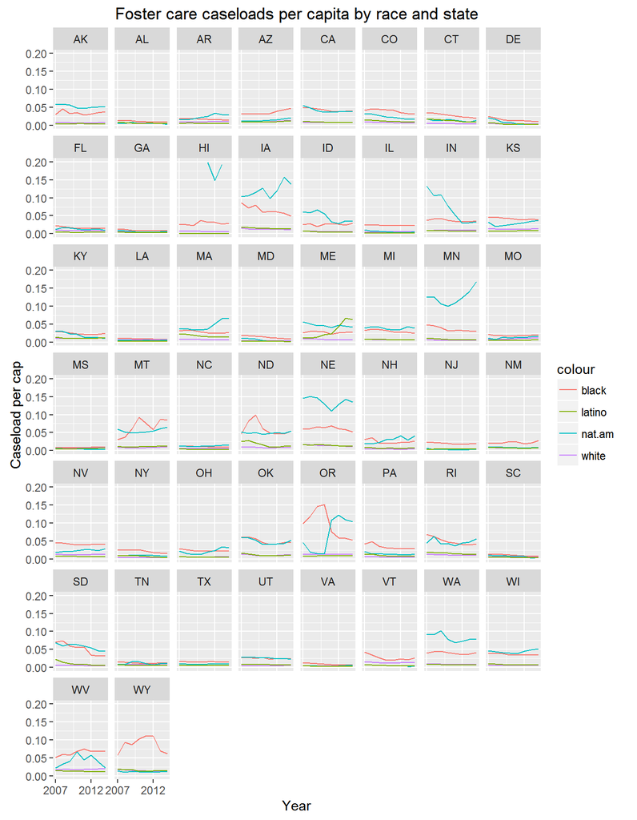

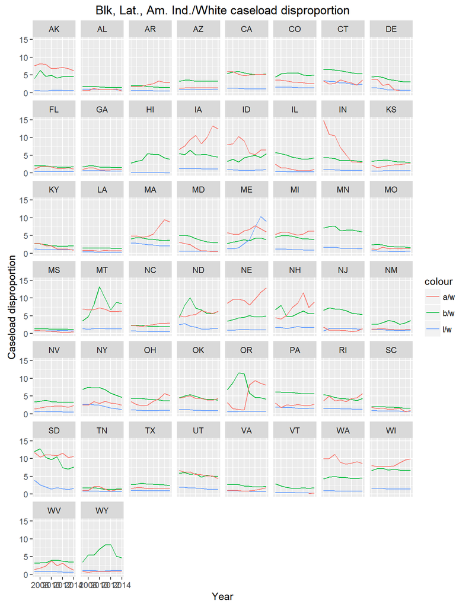

These are count models for each group. Performing relatively well. Goal is to show that social policy affects FC by race.

To do

- write the thing. Look at Eckenrode, Fluke, Drake as examples

# Findings

Caseloads by race, state intercepts, state|year slopes

|  | **Black** | **Latino** | **Native American** |  |
| --- | --- | --- | --- | --- |
| Black incarceration | 0.24*** |  |  |  |
|  | (0.03) |  |  |  |
| Black unemployment | -0.02 |  |  |  |
|  | (0.01) |  |  |  |
| Black single parent | -0.03* |  |  |  |
|  | (0.02) |  |  |  |
| Black less than HS | -0.00 |  |  |  |
|  | (0.01) |  |  |  |
| Black child poverty | 0.05*** |  |  |  |
|  | (0.01) |  |  |  |
| Percent Black pop | -0.58*** |  |  |  |
|  | (0.09) |  |  |  |
| State leg. ideology | 0.03* | -0.02 | -0.00 |  |
|  | (0.01) | (0.02) | (0.05) |  |
| Violent crime per cap | 0.12** | 0.03 | 0.16 |  |
|  | (0.04) | (0.04) | (0.13) |  |
| Year | -0.21*** | 0.05 | -0.28*** |  |
|  | (0.04) | (0.03) | (0.05) |  |
| Latino incarceration |  | 0.11*** |  |  |
|  |  | (0.03) |  |  |
| Latino unemployment |  | -0.01 |  |  |
|  |  | (0.01) |  |  |
| Latino single parent |  | -0.04* |  |  |
|  |  | (0.02) |  |  |
| Latino less than HS |  | 0.13*** |  |  |
|  |  | (0.04) |  |  |
| Latino child poverty |  | -0.04 |  |  |
|  |  | (0.02) |  |  |
| Percent Latino pop |  | -1.50*** |  |  |
|  |  | (0.28) |  |  |
| Deportations per foreign born |  | -0.04 |  |  |
|  |  | (0.02) |  |  |
| Native American incarceration |  |  | 0.58*** |  |
|  |  |  | (0.10) |  |
| Native American unemployment |  |  | -0.04 |  |
|  |  |  | (0.04) |  |
| Native American single parent |  |  | -0.07* |  |
|  |  |  | (0.03) |  |
| Native American less than HS |  |  | -0.20*** |  |
|  |  |  | (0.04) |  |
| Native American child poverty |  |  | -0.06 |  |
|  |  |  | (0.04) |  |
| Percent Nat. Am. pop |  |  | -0.11 |  |
|  |  |  | (0.17) |  |
| AIC | 5727.26 | 5032.25 | 4645.86 |  |
| BIC | 5778.89 | 5087.85 | 4697.48 |  |
| Log Likelihood | -2850.63 | -2502.13 | -2309.93 |  |
| Num. obs. | 392 | 392 | 392 |  |
| Num. groups: obs | 392 | 392 | 392 |  |
| Num. groups: stname | 49 | 49 | 49 |  |
| Var: obs (Intercept) | 0.01 | 0.01 | 0.09 |  |
| Var: stname (Intercept) | 13.08 | 27.57 | 14.93 |  |
| Var: stname year.c | 0.04 | 0.00 | 0.08 |  |
| Cov: stname (Intercept) year.c | -0.73 | 0.14 | -1.02 |  |
| p < 0.001, p < 0.01, p < 0.05 |  |  |  |  |

Caseload disproportion by race, state intercepts, state|year slopes

|  | **Black** | **Latino** | **Native American** |  |
| --- | --- | --- | --- | --- |
| B/W incarceration | 0.38*** |  |  |  |
|  | (0.03) |  |  |  |
| B/W child poverty | 0.06*** |  |  |  |
|  | (0.01) |  |  |  |
| B/W unemployment | -0.01 |  |  |  |
|  | (0.01) |  |  |  |
| B/W single parent | -0.02 |  |  |  |
|  | (0.01) |  |  |  |
| B/W less than HS | -0.00 |  |  |  |
|  | (0.01) |  |  |  |
| Percent Black pop | -0.44*** |  |  |  |
|  | (0.09) |  |  |  |
| State leg. ideology | 0.01 | -0.02 | -0.01 |  |
|  | (0.01) | (0.02) | (0.06) |  |
| Violent crime per cap | 0.07 | -0.01 | 0.10 |  |
|  | (0.04) | (0.03) | (0.10) |  |
| Year | 0.06*** | -0.01 | -0.01 |  |
|  | (0.00) | (0.01) | (0.02) |  |
| L/W incarceration |  | 0.17*** |  |  |
|  |  | (0.03) |  |  |
| L/W child poverty |  | 0.02 |  |  |
|  |  | (0.02) |  |  |
| Deportations per foreign born |  | 0.01 |  |  |
|  |  | (0.02) |  |  |
| L/W unemployment |  | 0.01 |  |  |
|  |  | (0.01) |  |  |
| L/W single parent |  | 0.02 |  |  |
|  |  | (0.02) |  |  |
| L/W less than HS |  | 0.06 |  |  |
|  |  | (0.04) |  |  |
| Percent Latino pop |  | -0.10 |  |  |
|  |  | (0.06) |  |  |
| N.A./W incarceration |  |  | 0.31* |  |
|  |  |  | (0.14) |  |
| N.A./W child poverty |  |  | 0.13* |  |
|  |  |  | (0.06) |  |
| N.A./W unemployment |  |  | 0.24*** |  |
|  |  |  | (0.07) |  |
| N.A./W single parent |  |  | -0.35*** |  |
|  |  |  | (0.05) |  |
| N.A./W less than HS |  |  | -0.23*** |  |
|  |  |  | (0.07) |  |
| Percent Nat. Am. pop |  |  | 0.03 |  |
|  |  |  | (0.19) |  |
| AIC | -238.57 | -268.46 | 849.51 |  |
| BIC | -186.94 | -212.86 | 901.13 |  |
| Log Likelihood | 132.28 | 148.23 | -411.75 |  |
| Num. obs. | 392 | 392 | 392 |  |
| Num. groups: stname | 49 | 49 | 49 |  |
| Var: stname (Intercept) | 1.90 | 0.13 | 1.49 |  |
| Var: stname year.c | 0.00 | 0.00 | 0.00 |  |
| Cov: stname (Intercept) year.c | -0.07 | -0.00 | 0.05 |  |
| Var: Residual | 0.01 | 0.01 | 0.26 |  |
| p < 0.001, p < 0.01, p < 0.05 |  |  |  |  |

# Discussion

Racism is an explanation - either systematic bias or structural racism is a likely cause of racial inequality in child welfare case outcomes.